# Creating images with R

with a little bit of magick

Akira Kalam

```css
@import url('https://fonts.googleapis.com/css2?family=Playfair+Display');
body {
  background-color: #D8BFD8;
  color: #51414F;
  font-family: 'Playfair Display', serif;
}
```

## Project requirements

I’ve met the requirements of working with Github by setting up an account, creating a repository called “stats 220”, and then creating a README.md file that demonstrates how I used markdown syntax to display two different levels of headers, two different types of bullet points, the use of bolds and italics, and the use of links to other websites. I used various levels of headers to outline the subjects for clarity and utilised bullet points, both listed and unlisted, to outline my purposes and the languages that I’ll be working with during the projects. Also, I used bold and italics for contrast and added links that redirect to the course outline and my Linkedin page.

This is the link to my Github repository https://github.com/akirakalam/stats220

**Project Folder**

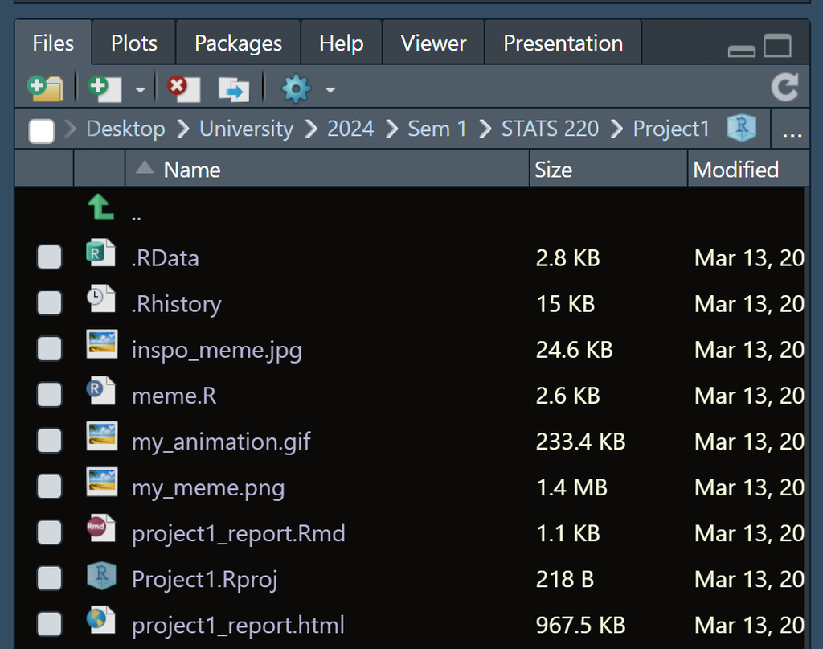

## My meme

**Meme Inspiration**

[figure not shown]

The key components of this meme I recreated were the four panels where the first row displays two squares that have annotated text within them and two images in the second row.

**My Meme**

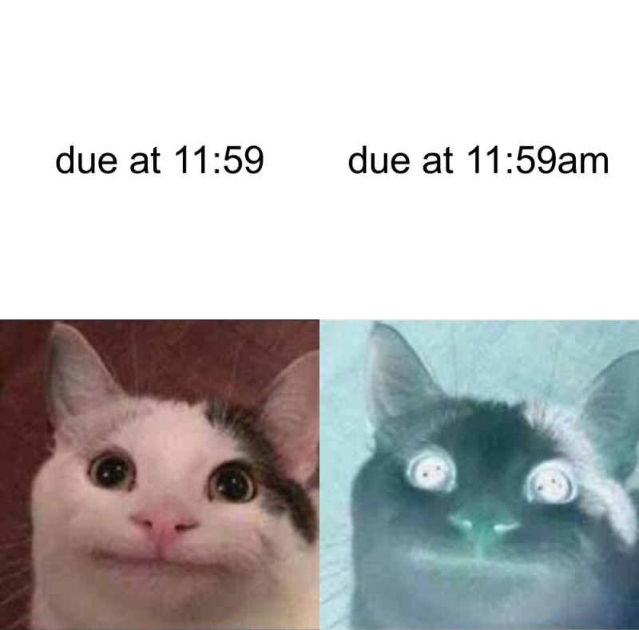

```r
library(magick)
# square one
stats_text1 <- image_blank(width = 500,
            height = 500,
            color = "#ffffff") %>%
  image_annotate(text = "due at 11:59",
                 color = "#000000",
                 size = 60,
                 font = "Arial",
                 gravity = "center")

# square 2
stats_text2 <- image_blank(width = 500,
                           height = 500,
                           color = "#ffffff") %>%
  image_annotate(text = "due at 11:59am",
                 color = "#000000",
                 size = 60,
                 font = "Arial",
                 gravity = "center")

# square 3
smiling_cat <- image_read("https://static.wikia.nocookie.net/herofanon/images/6/6a/Beluga.jpg/revision/latest/thumbnail/width/360/height/360?cb=20220727054706") %>%
  image_scale(500)

# square 4
doomed_cat <- image_read("https://static.wikia.nocookie.net/herofanon/images/6/6a/Beluga.jpg/revision/latest/thumbnail/width/360/height/360?cb=20220727054706") %>%
  image_scale(500) %>%
  image_negate

# first row
text_vector <- c(stats_text1, stats_text2)
top_row <- image_append(text_vector)

# second row
bottom_row <- image_append(c(smiling_cat, doomed_cat))

# final meme
my_meme <- c(top_row, bottom_row) %>%
  image_append(stack = TRUE) %>%
  image_scale(800)

# saving meme
image_write(my_meme, "my_meme.png")

my_meme
```

**My Animation**

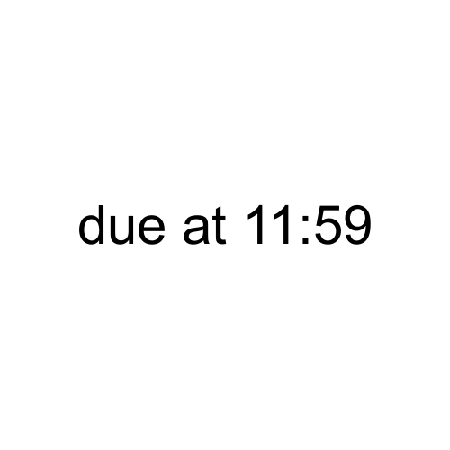

```r
#frame 1
frame1 <- image_blank(width = 500,
                      height = 500,
                      color = "#ffffff") %>%
  image_annotate(text = "due at 11:59",
                 color = "#000000",
                 size = 60,
                 font = "Arial",
                 gravity = "center")

#frame 2
frame2 <- image_read("https://static.wikia.nocookie.net/herofanon/images/6/6a/Beluga.jpg/revision/latest/thumbnail/width/360/height/360?cb=20220727054706") %>%
  image_scale(520)

#frame 3
frame3 <- image_blank(width = 500,
                      height = 500,
                      color = "#ffffff") %>%
  image_annotate(text = "due at 11:59am",
                 color = "#000000",
                 size = 60,
                 font = "Arial",
                 gravity = "center")

# frame 4
frame4 <- image_read("https://static.wikia.nocookie.net/herofanon/images/6/6a/Beluga.jpg/revision/latest/thumbnail/width/360/height/360?cb=20220727054706") %>%
  image_scale(520) %>%
  image_negate

# frames put together
frames <- c(frame1, frame2, frame3, frame4)

# final animation
animated_meme <- image_animate(frames, fps = 1)

# save animation
image_write(animated_meme, "my_animation.gif")
```

## Learning reflection

One vital realisation I had was the distinction between markup languages like Markdown and HTML and actual programming languages. Understanding that Markdown and HTML primarily serve for design and display purposes rather than executing algorithms or logic. It empathised with how closely intertwined they are and how they collectively contribute to the structure and presentation of web content.

For further exploration, I’m keen on delving into how R and Markdown intertwine and complement each other. Understanding how Markdown can be utilised in conjunction with R for dynamic reporting and documentation purposes is an area I’m eager to explore. Learning to effectively use Markdown within RStudio to create analyses, reports, and presentations would be immensely valuable.